# Practical ML Project

M M

2025-09-19

## 1. Overview

We predict how barbell lifts were performed (“classe”: A–E) from wearable sensor data (belt, forearm, arm, dumbbell). We split the provided training set into train/validation, compare several models using cross-validation, report expected out-of-sample (OOS) error, and use the best model to predict the 20 test cases.

## 2. Data & Preprocessing

We use the course datasets and standard cleaning steps for this assignment: - Remove columns with >95% missing. - Drop non-predictive identifiers / timestamps. - Remove near-zero-variance predictors. - Keep only predictors present in both train & test after cleaning.

```r
library(caret)
library(tidyverse)

train_url <- "https://d396qusza40orc.cloudfront.net/predmachlearn/pml-training.csv"
test_url  <- "https://d396qusza40orc.cloudfront.net/predmachlearn/pml-testing.csv"

train_raw <- read.csv(train_url, na.strings = c("NA", "", "#DIV/0!"))
test_raw  <- read.csv(test_url,  na.strings = c("NA", "", "#DIV/0!"))

# Drop columns with >95% NA in training
na_rate <- colSums(is.na(train_raw)) / nrow(train_raw)
keep_na <- names(na_rate[na_rate < 0.95])

train1 <- train_raw[, keep_na]
test1  <- test_raw[,  intersect(keep_na, names(test_raw))]

# Remove non-predictive columns (IDs / time / window flags)
drop_cols <- c("X","user_name","raw_timestamp_part_1","raw_timestamp_part_2",
               "cvtd_timestamp","new_window","num_window","problem_id")
train2 <- train1[, setdiff(names(train1), drop_cols)]
test2  <- test1[,  setdiff(names(test1),  drop_cols)]

# Ensure outcome factor present
train2$classe <- factor(train2$classe)

# Remove near-zero-variance predictors
nzv <- nearZeroVar(train2, saveMetrics = TRUE)
train3 <- train2[, !nzv$nzv]
test3  <- test2[,  intersect(names(train2)[!nzv$nzv], names(test2))]

# Align columns between train and test (excluding outcome)
predictors <- setdiff(names(train3), "classe")
test3 <- test3[, predictors]
dim(train3); dim(test3)
```

```
## [1] 19622    53
```

```
## [1] 20 52
```

## 3. Train/Validation Split & Cross-Validation

We hold out 30% for validation and perform 5-fold CV inside training.

```r
set.seed(2025)
inTrain <- createDataPartition(train3$classe, p = 0.70, list = FALSE)
trn <- train3[inTrain, ]
val <- train3[-inTrain, ]

ctrl <- trainControl(method = "cv", number = 5, classProbs = TRUE, allowParallel = TRUE,
                     summaryFunction = multiClassSummary)
```

## 4. Models

We compare a Random Forest, Gradient Boosting (GBM), and a simple CART tree.

```r
# Random Forest
rf_fit <- train(classe ~ ., data = trn, method = "rf",
                trControl = ctrl, tuneLength = 3, ntree = 500)

# GBM
gbm_fit <- train(classe ~ ., data = trn, method = "gbm",
                 trControl = ctrl, tuneLength = 3, verbose = FALSE)

# CART (rpart)
cart_fit <- train(classe ~ ., data = trn, method = "rpart",
                  trControl = ctrl, tuneLength = 5)

rf_fit; gbm_fit; cart_fit
```

```
## Random Forest
##
## 13737 samples
##    52 predictor
##     5 classes: 'A', 'B', 'C', 'D', 'E'
##
## No pre-processing
## Resampling: Cross-Validated (5 fold)
## Summary of sample sizes: 10990, 10991, 10989, 10988, 10990
## Resampling results across tuning parameters:
##
##   mtry  logLoss     AUC        prAUC      Accuracy   Kappa      Mean_F1
##    2    0.19655974  0.9997970  0.9803113  0.9906096  0.9881206  0.9897768
##   27    0.09625531  0.9997972  0.8697935  0.9904637  0.9879361  0.9896718
##   52    0.09638176  0.9993505  0.7526470  0.9835489  0.9791850  0.9825152
##   Mean_Sensitivity  Mean_Specificity  Mean_Pos_Pred_Value  Mean_Neg_Pred_Value
##   0.9894666         0.9976575         0.9901886            0.9977085
##   0.9893704         0.9976183         0.9900411            0.9976686
##   0.9820350         0.9958665         0.9831170            0.9959538
##   Mean_Precision  Mean_Recall  Mean_Detection_Rate  Mean_Balanced_Accuracy
##   0.9901886       0.9894666    0.1981219            0.9935621
##   0.9900411       0.9893704    0.1980927            0.9934944
##   0.9831170       0.9820350    0.1967098            0.9889507
##
## Accuracy was used to select the optimal model using the largest value.
## The final value used for the model was mtry = 2.
```

```
## Stochastic Gradient Boosting
##
## 13737 samples
##    52 predictor
##     5 classes: 'A', 'B', 'C', 'D', 'E'
##
## No pre-processing
## Resampling: Cross-Validated (5 fold)
## Summary of sample sizes: 10990, 10989, 10991, 10988, 10990
## Resampling results across tuning parameters:
##
##   interaction.depth  n.trees  logLoss    AUC        prAUC      Accuracy
##   1                   50      0.8852677  0.9331498  0.8084053  0.7487087
##   1                  100      0.7015875  0.9607726  0.8776595  0.8184466
##   1                  150      0.5896752  0.9730179  0.9118317  0.8522973
##   2                   50      0.6284359  0.9730032  0.9142428  0.8529532
##   2                  100      0.4245760  0.9883146  0.9584142  0.9071116
##   2                  150      0.3188927  0.9932120  0.9738400  0.9312072
##   3                   50      0.4814683  0.9857150  0.9516116  0.8967022
##   3                  100      0.2939343  0.9947661  0.9794899  0.9428544
##   3                  150      0.2076620  0.9974983  0.9882906  0.9593803
##   Kappa      Mean_F1    Mean_Sensitivity  Mean_Specificity  Mean_Pos_Pred_Value
##   0.6812508  0.7416322  0.7390965         0.9362755         0.7540230
##   0.7702017  0.8133716  0.8125268         0.9542309         0.8194500
##   0.8130942  0.8480434  0.8473850         0.9628036         0.8521960
##   0.8135860  0.8485100  0.8455632         0.9626915         0.8551633
##   0.8824169  0.9034889  0.9023075         0.9766284         0.9061644
##   0.9129337  0.9280306  0.9271295         0.9827281         0.9298401
##   0.8691983  0.8932340  0.8916637         0.9739200         0.8967692
##   0.9276773  0.9403386  0.9394223         0.9856363         0.9418698
##   0.9486047  0.9573742  0.9567465         0.9898174         0.9582854
##   Mean_Neg_Pred_Value  Mean_Precision  Mean_Recall  Mean_Detection_Rate
##   0.9373430            0.7540230       0.7390965    0.1497417
##   0.9546302            0.8194500       0.8125268    0.1636893
##   0.9630677            0.8521960       0.8473850    0.1704595
##   0.9634206            0.8551633       0.8455632    0.1705906
##   0.9769019            0.9061644       0.9023075    0.1814223
##   0.9829368            0.9298401       0.9271295    0.1862414
##   0.9742930            0.8967692       0.8916637    0.1793404
##   0.9858177            0.9418698       0.9394223    0.1885709
##   0.9899203            0.9582854       0.9567465    0.1918761
##   Mean_Balanced_Accuracy
##   0.8376860
##   0.8833788
##   0.9050943
##   0.9041273
##   0.9394680
##   0.9549288
##   0.9327918
##   0.9625293
##   0.9732819
##
## Tuning parameter 'shrinkage' was held constant at a value of 0.1
##
## Tuning parameter 'n.minobsinnode' was held constant at a value of 10
## Accuracy was used to select the optimal model using the largest value.
## The final values used for the model were n.trees = 150, interaction.depth =
##  3, shrinkage = 0.1 and n.minobsinnode = 10.
```

```
## CART
##
## 13737 samples
##    52 predictor
##     5 classes: 'A', 'B', 'C', 'D', 'E'
##
## No pre-processing
## Resampling: Cross-Validated (5 fold)
## Summary of sample sizes: 10990, 10990, 10990, 10989, 10989
## Resampling results across tuning parameters:
##
##   cp          logLoss   AUC        prAUC       Accuracy   Kappa       Mean_F1
##   0.02736242  1.170370  0.7764664  0.30571166  0.5326508  0.38993034  0.4939014
##   0.03061743  1.187093  0.7700723  0.29071668  0.5210745  0.37420154  0.4787356
##   0.04119622  1.219695  0.7439129  0.26511114  0.4910083  0.33486352        NaN
##   0.04948632  1.267847  0.7083876  0.22017753  0.4604407  0.28596480        NaN
##   0.11514597  1.527896  0.5350073  0.02509051  0.3162921  0.04896457        NaN
##   Mean_Sensitivity  Mean_Specificity  Mean_Pos_Pred_Value  Mean_Neg_Pred_Value
##   0.4874530         0.8767688         0.5829763            0.8886861
##   0.4724320         0.8738221         0.5681521            0.8863217
##   0.4372195         0.8665395               NaN            0.8801839
##   0.4021939         0.8565456               NaN            0.8753058
##   0.2353881         0.8089824               NaN            0.8626357
##   Mean_Precision  Mean_Recall  Mean_Detection_Rate  Mean_Balanced_Accuracy
##   0.5829763       0.4874530    0.10653016           0.6821109
##   0.5681521       0.4724320    0.10421491           0.6731271
##         NaN       0.4372195    0.09820167           0.6518795
##         NaN       0.4021939    0.09208813           0.6293698
##         NaN       0.2353881    0.06325842           0.5221852
##
## Accuracy was used to select the optimal model using the largest value.
## The final value used for the model was cp = 0.02736242.
```

Cross-validated comparison (Accuracy)

```r
res <- resamples(list(RandomForest = rf_fit, GBM = gbm_fit, CART = cart_fit))
summary(res)
```

```
##
## Call:
## summary.resamples(object = res)
##
## Models: RandomForest, GBM, CART
## Number of resamples: 5
##
## Accuracy
##                   Min.   1st Qu.    Median      Mean   3rd Qu.      Max. NA's
## RandomForest 0.9894469 0.9898145 0.9908992 0.9906096 0.9912600 0.9916272    0
## GBM          0.9552565 0.9555879 0.9603059 0.9593803 0.9617904 0.9639607    0
## CART         0.5058224 0.5180197 0.5352984 0.5326508 0.5489625 0.5551511    0
##
## AUC
##                   Min.   1st Qu.    Median      Mean   3rd Qu.      Max. NA's
## RandomForest 0.9997144 0.9997638 0.9998266 0.9997970 0.9998322 0.9998480    0
## GBM          0.9969197 0.9971652 0.9974332 0.9974983 0.9979529 0.9980204    0
## CART         0.7560006 0.7678364 0.7759857 0.7764664 0.7905088 0.7920006    0
##
## Kappa
##                   Min.   1st Qu.    Median      Mean   3rd Qu.      Max. NA's
## RandomForest 0.9866520 0.9871110 0.9884879 0.9881206 0.9889436 0.9894088    0
## GBM          0.9434031 0.9437829 0.9497941 0.9486047 0.9516433 0.9544003    0
## CART         0.3545097 0.3717948 0.3931743 0.3899303 0.4107592 0.4194137    0
##
## logLoss
##                   Min.   1st Qu.    Median      Mean   3rd Qu.      Max. NA's
## RandomForest 0.1924522 0.1951681 0.1973463 0.1965597 0.1975044 0.2003278    0
## GBM          0.2024835 0.2030786 0.2061987 0.2076620 0.2082140 0.2183350    0
## CART         1.1322122 1.1377099 1.1762225 1.1703701 1.1922912 1.2134145    0
##
## Mean_Balanced_Accuracy
##                   Min.   1st Qu.    Median      Mean   3rd Qu.      Max. NA's
## RandomForest 0.9928645 0.9930477 0.9936714 0.9935621 0.9939733 0.9942536    0
## GBM          0.9706362 0.9708699 0.9741909 0.9732819 0.9748776 0.9758351    0
## CART         0.6636321 0.6726124 0.6834173 0.6821109 0.6928149 0.6980777    0
##
## Mean_Detection_Rate
##                   Min.   1st Qu.    Median      Mean   3rd Qu.      Max. NA's
## RandomForest 0.1978894 0.1979629 0.1981798 0.1981219 0.1982520 0.1983254    0
```

[output cut: 35 more lines]

```
## RandomForest 0.9883459 0.9887054 0.9895826 0.9894666 0.9901200 0.9905791    0
## GBM          0.9524913 0.9529048 0.9582949 0.9567465 0.9594048 0.9606368    0
## CART         0.4571941 0.4717029 0.4894615 0.4874530 0.5049932 0.5139131    0
##
## Mean_Specificity
##                   Min.   1st Qu.    Median      Mean   3rd Qu.      Max. NA's
## RandomForest 0.9973830 0.9973900 0.9977601 0.9976575 0.9978265 0.9979280    0
## GBM          0.9887811 0.9888351 0.9900869 0.9898174 0.9903505 0.9910333    0
## CART         0.8700701 0.8735219 0.8773731 0.8767688 0.8806366 0.8822424    0
##
## prAUC
##                   Min.   1st Qu.    Median      Mean   3rd Qu.      Max. NA's
## RandomForest 0.9763189 0.9794561 0.9798177 0.9803113 0.9807165 0.9852473    0
## GBM          0.9862159 0.9866165 0.9880461 0.9882906 0.9901187 0.9904557    0
## CART         0.2756891 0.2776181 0.3028110 0.3057117 0.3348142 0.3376259    0
```

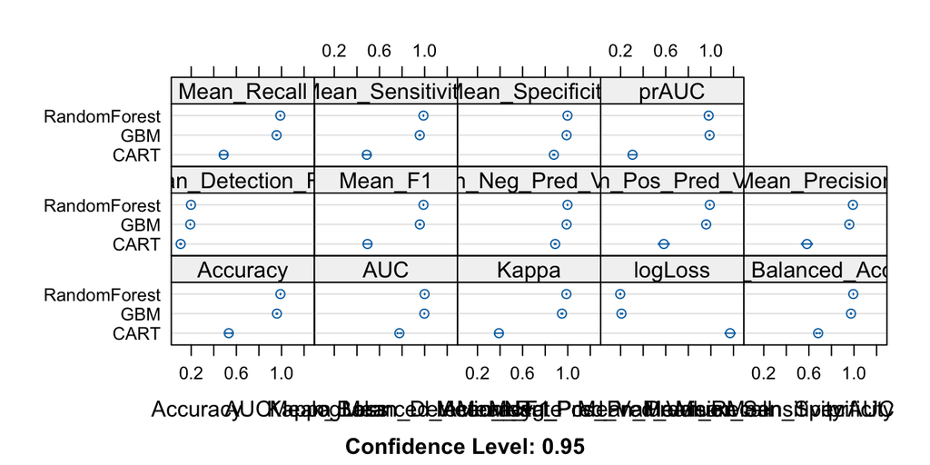

```r
dotplot(res)
```

Figure 1: Cross-validated accuracy across models (5-fold CV).

## 5. Validation Performance & Expected OOS Error

We evaluate on the 30% hold-out validation set. Our expected OOS error ≈ 1 − accuracy(val) for the chosen model.

```r
pred_rf  <- predict(rf_fit,  val)
pred_gbm <- predict(gbm_fit, val)
pred_ct  <- predict(cart_fit, val)

cm_rf  <- confusionMatrix(pred_rf,  val$classe)
cm_gbm <- confusionMatrix(pred_gbm, val$classe)
cm_ct  <- confusionMatrix(pred_ct,  val$classe)

acc_table <- tibble(
  Model = c("Random Forest", "GBM", "CART"),
  Accuracy = c(cm_rf$overall["Accuracy"], cm_gbm$overall["Accuracy"], cm_ct$overall["Accuracy"])
)
acc_table
```

```
## # A tibble: 3 × 2
##   Model         Accuracy
##   <chr>            <dbl>
## 1 Random Forest    0.993
## 2 GBM              0.963
## 3 CART             0.529
```

Chosen model: Random Forest (highest accuracy). Validation accuracy (RF): 0.9932 Expected OOS error: 0.0068

Variable Importance (top drivers)

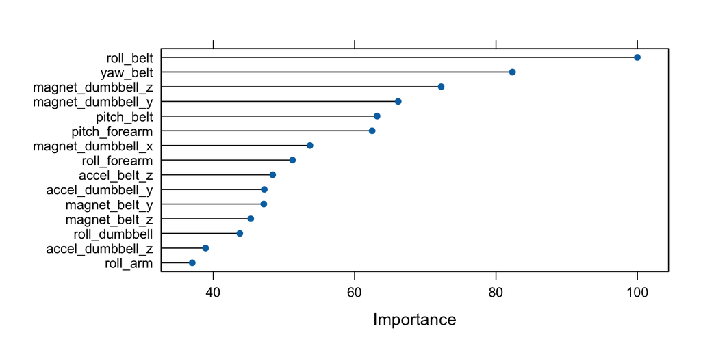

```r
vi <- varImp(rf_fit)
plot(vi, top = 15)
```

Figure 2: Top predictors by RF variable importance.

## 6. Predict the 20 Test Cases

We apply the chosen model (RF) to the cleaned test set and create the 20 submission files.

```r
pred_test <- predict(rf_fit, test3)
pred_test
```

```
##  [1] B A B A A E D B A A B C B A E E A B B B
## Levels: A B C D E
```

```r
pml_write_files <- function(x) {
  for (i in seq_along(x)) {
    fn <- paste0("problem_id_", i, ".txt")
    write.table(x[i], file = fn, quote = FALSE, row.names = FALSE, col.names = FALSE)
  }
}
pml_write_files(pred_test)
```